# Structural Models

73-374 Econometrics II

## Today

- Using structural models to perform causal inference
- Represent structural relationships between variables using
  - Systems of equations
  - Causal Diagrams
- Structural models have implications for conditional independence
  - Use these to justify causal interpretation of regression

## Review of Control

- Last class, covered causal inference using *control*
- **Conditionally random assignment** is key condition
  $$Y^x\perp X|W$$
- If true, average causal effect is identified by the formula
  $$E(Y^x)=\int E(Y|X=x,W=w)P(w)dw$$
- If conditional expectation function is linear, $E(Y|X=x,W=w)$ recovered by coefficient $\beta_1$ in regression
  $$Y=\beta_0+\beta_1X+\gamma W+e$$
- Big question: when is conditional random assignment a reasonable assumption
  - Answer: relies on *causal model* of variables, expressed as system of equations

## Structural Equations

- A **structural equation** represents the effect of variables that directly cause an outcome
- Describes a model of how a variable is generated, and how it would change if other variables were changed
- $Y=f(X,U)$, $U\perp X$ is *structural* if
  $$P(Y|do(X=x))=P(f(x,U))$$
- Assuming linear structural form, i.e., for $U\perp X$,
  $$Y=\beta_0 + \beta_1X_1+\beta_2X_2+\beta_3X_3+\ldots+U$$
  - *Each* coefficient $\beta_j$ gives the direct causal effect of $X_j$ on $Y$
- A structural equation is distinct from a regression equation
  - Regression equation is what you estimate
    - Can always run, given data
  - Structural equation is model of the world
    - May or may not be same as what you run

## Structural Equation Models

- A structural equation *model* (**SEM**) describes full set of causal relationships between variables in a system
- Each **endogenous** variable $Y_1,Y_2,\ldots,Y_p$ described by structural equation
  $$Y_1=f_1(Y_2,\ldots,Y_p,U_1)$$
  $$Y_2=f_2(Y_1,Y_3,\ldots,Y_p,U_2)$$
  $$\vdots$$
  $$Y_p=f_p(Y_1,Y_2,\ldots,Y_{p-1},U_p)$$
- Each structural equation contains only direct causes
  - Variables $Y_j$ with no effect are *excluded*
- Variables $U$ are **exogenous**
  - Not caused by any variable $Y$ in system

## Causal Graphs (Code)

```r
#Library to create and analyze causal graphs
library(dagitty)
library(ggdag) #library to plot causal graphs
yxdag<-dagify(Y~X) #create graph with arrow from X to Y
#Set position of nodes so they lie on a straight line
  coords<-list(x=c(X = 0, Y = 1),y=c(X = 0, Y = 0))
  coords_df<-coords2df(coords)
  coordinates(yxdag)<-coords2list(coords_df)
#Plot causal graph
ggdag(yxdag)+theme_dag_blank()+
  labs(title="X causes Y",
  subtitle="X is a parent of Y, Y is a child of X")
```

## Causal Graphs

- A structural equation model can be represented as a graph
  - Variables are **nodes**: box or circle
  - Direct causal effects are (directed) **edges**: lines with arrows indicating direction
  - Nodes at source of arrow are called **parents**, nodes at ends are **children**
- Simplest example: structural equation model
  - $Y=f_1(X,U_y)$ $X=f_2(U_2)$
- Graph by R packages `dagitty` and `ggdag`

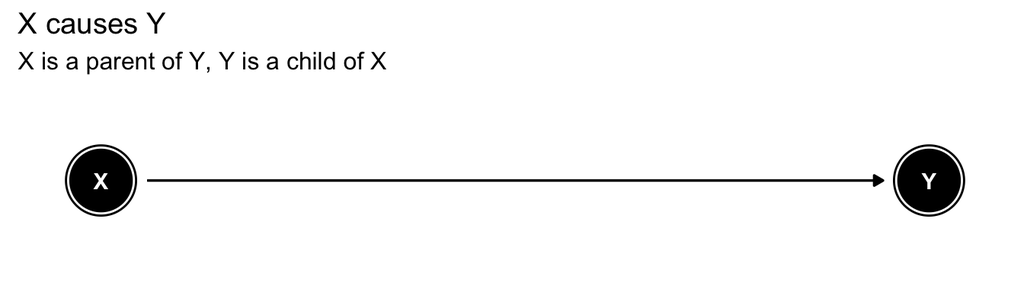

- $U_1,U_2$ not shown explicitly: $X$ and $Y$ are variables of interest, with exogenous random variation caused by $U_1,U_2$

## Implications of structural equations models

- To go from an SEM to distribution of data, *solve* the system of equations
  - Find endogenous variables $Y$ as function of only exogenous variables $U$
  - Known distribution of $U$ then gives joint distribution of $Y$
- Today, restrict interest to **acyclic** structural models
  - Causal graph does not contain path along directed edges from a variable to itself
  - Variables do not cause themselves
  - Further, assume $(U_1,\ldots,U_p)$ are *mutually independent*
- For acyclic models, solve by
  - Start with variables with no incoming arrows
  - Substitute variable in direction of arrows for its structural equation
  - Repeat until no endogenous variable appears on lefthand side
- Resulting model is called the **reduced form**

## Example: Solving a structural model (Code)

```r
examplegraph<-dagify(Y3~Y2,Y4~Y3+Y2,Y2~Y1) #create graph
#Set position of nodes
coords<-list(x=c(Y1 = 0, Y2 = 1, Y3 = 2, Y4 = 3),
         y=c(Y1 = 0, Y2 = 0, Y3 = -0.1, Y4 = 0))
coords_df<-coords2df(coords)
coordinates(examplegraph)<-coords2list(coords_df)

#Plot causal graph
ggdag(examplegraph)+theme_dag_blank()
  +labs(title="Y1 causes Y2,
        Y2 causes Y3, Y3 and Y2 cause Y4")
```

## Example: Solving a structural model

- $Y_1=f_1(U_1)$, $Y_2=f_2(Y_1,U_2)$, $Y_3=f_3(Y_2,U_3)$, $Y_4=f_4(Y_3,Y_2,U_4)$

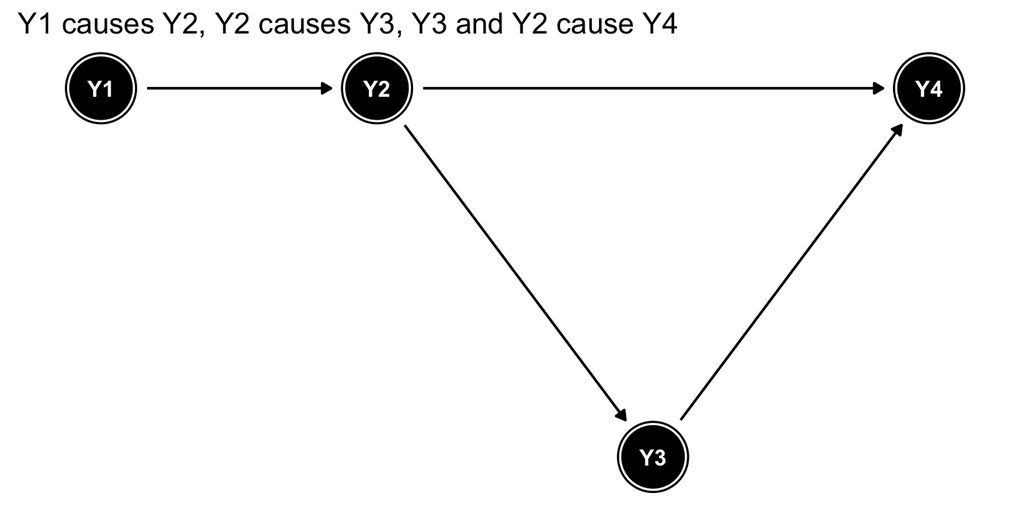

- To solve, start at $Y_1$, replace in $Y_2$ to get
  - $Y_1=f_1(U_1)$, $Y_2=f_2(f_1(U_1),U_2)$
- Then substitute out for $Y_2$
  - $Y_3=f_3(f_2(f_1(U_1),U_2),U_3)$, $Y_4=f_4(Y_3,f_2(f_1(U_1),U_2),U_4)$
- Substitute out for $Y_3$ to get reduced form
  - $Y_4=f_4(f_3(f_2(f_1(U_1),U_2),U_3),f_2(f_1(U_1),U_2),U_4)$

## Interpreting a structural equation model

- Solving an acyclic structural model gives joint distribution of endogenous variables
- What properties does the joint distribution have?
  - **Causal Markov property**:
  - Conditional on its parents, a variable is independent of any variable that is not a *descendant*
  - $Y_k$ is a **descendant** of $Y_j$ if there is a path along directed edges from $Y_j$ to $Y_k$
- Causal Markov Property completely defines implications of causal graph
  - Absence of an edge means conditional independence
- In above example, applying this rule gives the following conditional indepencies

```r
impliedConditionalIndependencies(examplegraph)
```

```
## Y1 _||_ Y3 | Y2
## Y1 _||_ Y4 | Y2
```

## Every SEM tells a story

- Omitted edges imply conditional independence
  - Only remove edge if you *know* there is *no* direct effect
- Direction of edges describe direction of effect
- **Total effect** includes indirect effect through other variables
  - In linear additive case, effect along directed path from X to Y is product of SEM coefficients
  - Total effect is sum of effects along all directed paths
- Example fitting above graph
  - $Y4$ is wages, $Y3$ is social connections, $Y2$ is education, $Y1$ is a randomly assigned admissions decision
- Story says wages determined by social connections and education, and education affects social connections, and admission affects education but has no direct effect on other variables except through it
- Use model to make assumptions clear, and if we believe them, determine which effects we can estimate

## “Do” operation and causal interventions

- The effect of a causal intervention can be explicitly calculated in an SEM using the **Do** operation
- **Do $Y_j=y$** describes action of setting a variable $Y_j$ to a specific value $y$
  - Remove equation $Y_j=f_j(...)$ and replace by $Y_j=y$
  - Solve new SEM to get distribution of any variable $P(Y_k|do(Y_j=y))$
- Equivalently, on causal graph
  - Delete all directed edges pointing in to node $Y_j$
  - New graph describes all relationships in world where $Y_j$ has been changed
- In potential outcomes notation, $Y_k^{Y_j=y}$ is distribution of $Y_k$ in the perturbed SEM
- A “Causal effect” describes what world would be like if instead of its usual value, some variable were changed
- SEM allows calculating distribution of both observed and potential outcomes
  - Can use relationship to identify causal effects

## Example: Experiments (Code)

```r
#Set position of nodes so they lie on a straight line
  coords<-list(x=c(X = 0, Y = 1),y=c(X = 0, Y = 0))
  coords_df<-coords2df(coords)
  coordinates(yxdag)<-coords2list(coords_df)
ggdag(yxdag)+theme_dag_blank() #Plot causal graph
```

## Example: Experiments

- In an experiment, $X$ is set (randomly) by experimenter, so has no incoming edges
  - $X=f_1(U_1)$
- Outcome of interest $Y$ has only $X$ and $U_2$, variables independent of $X$ as inputs
  - $Y=f_2(X,U_2)$
- Causal graph is therefore

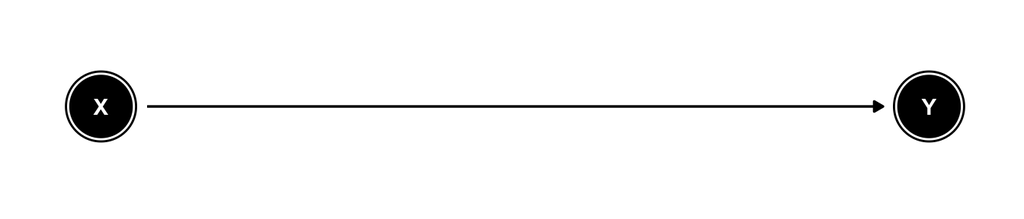

- $Do(X=x)$ deletes all incoming edges to X
  - There are none, so graph is unchanged
  - Using perturbed graph $P(Y|do(X=x))=P(f_2(x,U_2))$
  - In original graph $P(Y|X=x)=P(f_2(X,U_2)|X=x)=P(f_2(x,U_2))$ by $U_1\perp U_2$
- Result: $P(Y|do(X=x))=P(Y|X=x)$
  - Exactly as derived in potential outcomes framework

## Example 2: Confounding (Code 1)

```r
confoundgraph<-dagify(Y~X+W,X~W) #create graph
#Set position of nodes
coords<-list(x=c(X = 0, W = 1, Y = 2),
        y=c(X = 0, W = -0.1, Y = 0))
coords_df<-coords2df(coords)
coordinates(confoundgraph)<-coords2list(coords_df)
#Plot causal graph
ggdag(confoundgraph)+theme_dag_blank()
  labs(title="Confounding of effect of X on Y by W")
```

## Example 2: Confounding (Code 2)

```r
perturbedgraph<-dagify(Y~x+W) #create graph
#Set position of nodes
coords<-list(x=c(x = 0, W = 1, Y = 2),
            y=c(x = 0, W = -0.1, Y = 0))
coords_df<-coords2df(coords)
coordinates(perturbedgraph)<-coords2list(coords_df)

#Plot causal graph
ggdag(perturbedgraph)+theme_dag_blank()+
  labs(title="Perturbed Graph")
```

## Example 2: Confounding

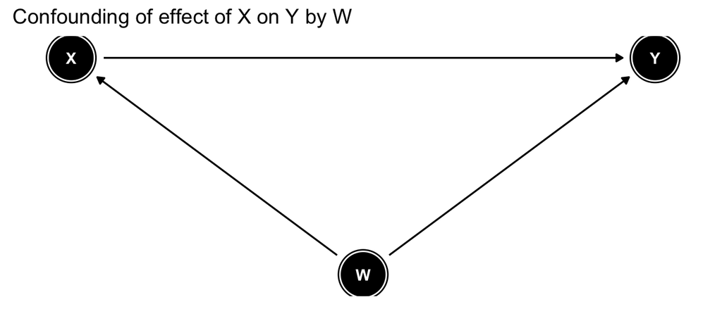

- Suppose we care about effect of X on Y
  - But W causes both X and Y
- Recover $P(Y=y|do(X=x))$ by constructing perturbed graph

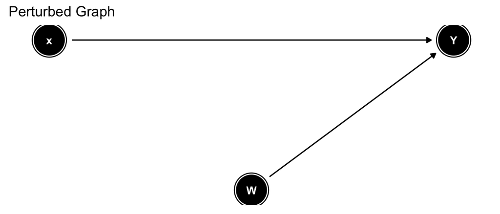

## Recovering the adjustment formula using causal graphs

- Causal Markov property in perturbed graph implies
  $$Pr(Y=y,W=w,X=x|do(X=x))=$$
  $$Pr(Y=y|W=w,X=x,do(X=x))Pr(W=w|do(X=x))\cdot$$
  $$Pr(X=x|do(X=x))$$
- Using that conditional laws are unchanged in perturbed graph
  $$=Pr(Y=y|W=w,X=x)Pr(W=w)$$
- Object of interest $P(Y=y|do(X=x))=$
  $$\int\int Pr(Y=y|W=w,X=x,do(X=x))Pr(W=w|do(X=x))\cdot$$
  $$Pr(X=x|do(X=x))dwdx$$
- Substitute in to get adjustment formula: $P(Y=y|do(X=x))=$
  $$\int Pr(Y=y|W=w,X=x)Pr(W=w)dw$$

## What have we learned so far?

- Introduced notation for Stuctural Equations, causal graphs
- Recover same results as in potential outcomes framework for experiments, adjustment
  - This is general: just different notation for same model
- So why bother, aside from pretty pictures?
  - Sometimes, relationship between variables takes different form
  - Rules of structural equation models can handle many new results
  - May require complicated algebra, but can be automated
- Next, show a few graphs representing alternative situations

## Mediators

```r
mediatorgraph<-dagify(Y~W,W~X) #create graph
#Set position of nodes
coords<-list(x=c(X = 0, W = 1, Y = 2),
          y=c(X = 0, W = 0, Y = 0))
coords_df<-coords2df(coords)
coordinates(mediatorgraph)<-coords2list(coords_df)

#Plot causal graph
ggdag(mediatorgraph)+theme_dag_blank()+
  labs(title="Mediator structure")
```

## Mediators

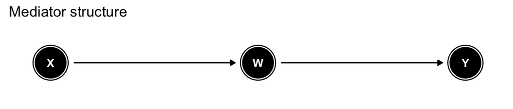

- Sometimes we have access to variables $W$ called **mediators**
  - Caused by treatment $X$ and also affect outcome
  - Executioner shoots (X) Bullet hits (W) Prisoner dies (Y)
- $P(Y|do(X=x))$ asks what is outcome when $X$ happens: $=P(Y|X=x)$
- $W$ is correlated with $X$ and $Y$, but **don’t** want to control for it
  - Adjustment formula gives 0 effect of $X$ on $Y$ if $W$ controlled for
  - $\int P(Y|X,W=w)P(w)dw=\int P(Y|W)P(W=w)dw=P(Y)\neq P(Y|do(X=x))$
- Conditional on being hit by a bullet, being shot at has no relationship with death
  - Changing $X$ does affect $Y$, but indirectly through $W$
- For confounders, control *removes* bias, for mediators *causes* it
  - Knowledge of causal model tells us how to interpret regression

## Colliders (Code)

```r
collidergraph<-dagify(W~Y,W~X) #create graph
#Set position of nodes
coords<-list(x=c(X = 0, W = 1, Y = 2),
               y=c(X = 0, W = 0, Y = 0))
coords_df<-coords2df(coords)
coordinates(collidergraph)<-coords2list(coords_df)

#Plot causal graph
ggdag(collidergraph)+theme_dag_blank()+
  labs(title="Collider structure")
```

## Colliders

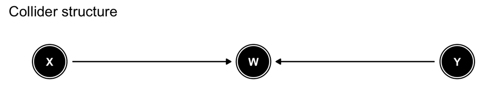

- A **collider** $W$ is caused by both $X$ and $Y$
- Grades $X$ and wealth $Y$ both help college admission $W$
- Unconditionally, $X\perp Y$
  - *But*, conditional on $W$, $X$ and $Y$ are dependent
  - Knowing $W$, $X$ is informative about $Y$
- Among college students, those with rich family did not need high grades to get in.
  - Observing rich family, can infer that likelihood of high grades was lower
  - True even if in full population, grades and wealth independent
- Controlling for collider in regression of $Y$ on $X$ causes bias
  - $P(Y|do(X=x))=P(Y|X=x)=P(Y)$ not equal to $\int P(Y|X,W=w)P(w)dw$
- Commonality with mediator case: $W$ is a *descendant* of $X$

## Summary

- Structural Equations Models describe full set of causal relationships between variables in a system
- Causal graphs represent structural equations models and the conditional independencies they imply
- Causal effects represented by “Do” operation, which asks what happens in a new graph where treatment is fixed rather than assigned by existing mechanism
- SEMs can describe situations like experiments and control, but also mediation, colliders, and more complicated structures
- Working through the implications of causal graphs yield rules to describe when adjustment by regression measures a causal effect

## References

- Short introduction
  - Kelleher, Adam. (2016) “A Technical Primer on Causality” https://medium.com/@akelleh/a-technical-primer-on-causality-181db2575e41
- Longer introduction
  - Nielsen, Michael. (2012) “If correlation doesn’t imply causation, then what does?” http://www.michaelnielsen.org/ddi/if-correlation-doesnt-imply-causation-then-what-does/
- Monograph: original primary source for this material.
  - Pearl, Judea. (2009) Causality: Models, Reasoning, and Inference. 2nd ed. Cambridge UP.
- Software: R packages to analyze and display causal graphs

```r
    install.packages("dagitty")
    install.packages("ggdag")
```